# Homework #12

Jules Ford

2023-04-19

For this homework since I don’t have my own data I’m going to use one of the datasets from ggplot2. I don’t know anything about diamonds as gemstones and there’s a whole dataset on them, so I’m going to make some plots to learn more!

First I want to load a few things in with the `library()` function and grab the data about diamonds.

```r
library(ggplot2) # loads the data
library(ggthemes)
library(patchwork)
library(tidyverse)
```

So first I want to see the relationship between carat and price, so I made a scatterplot:

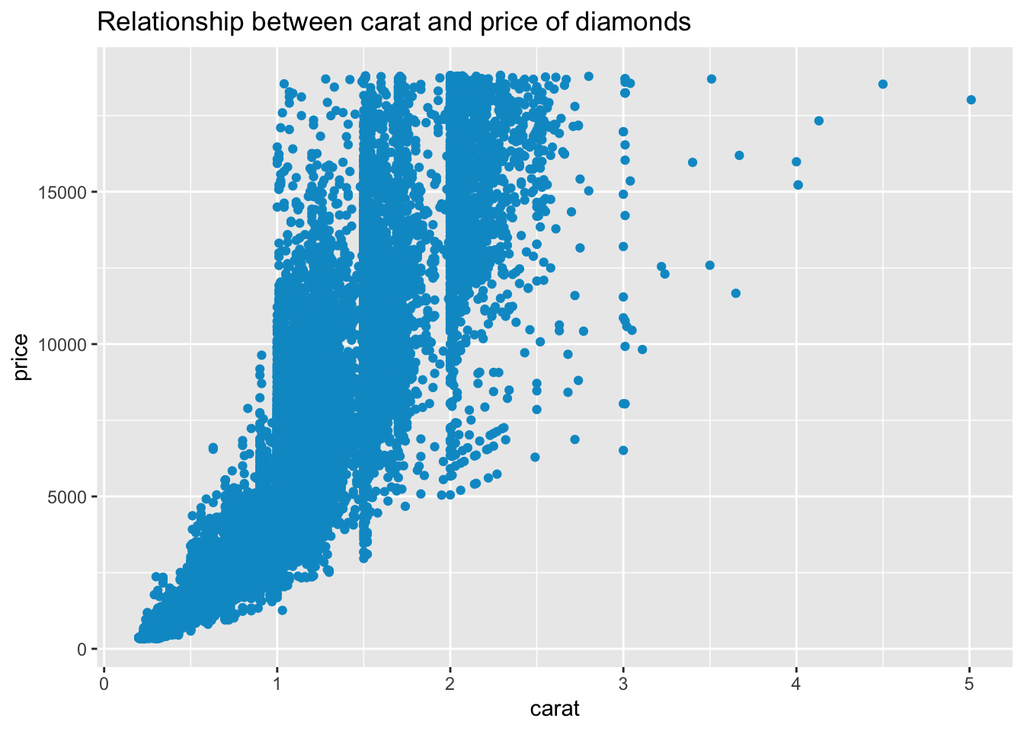

```r
caratVersusPrice <- ggplot(diamonds, aes(x=carat, y=price)) + geom_point(color="deepskyblue3", fill="blue") + ggtitle("Relationship between carat and price of diamonds")
print(caratVersusPrice)
```

Awesome. It seems like the higher the carat, the higher the price.

Now, I want to make a histogram of all the different cut types to have a sense of the quality of diamonds in the dataset. The cut variable is categorical, so I’m going to make a histogram.

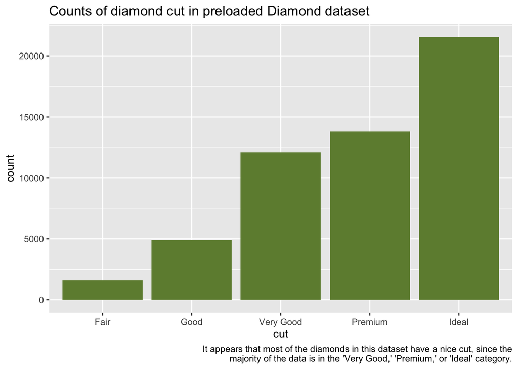

```r
cap = str_wrap("It appears that most of the diamonds in this dataset have a nice cut, since the majority of the data is in the 'Very Good,' 'Premium,' or 'Ideal' category.")

cutHistogram <- ggplot(diamonds, aes(x=cut)) + geom_bar(fill="darkolivegreen4") + ggtitle("Counts of diamond cut in preloaded Diamond dataset") + labs(caption=cap)

print(cutHistogram)
```

So this graph shows that the data have far more diamonds in higher quality cut categories than in the lower quality cut categories.

Now I want to make one more graph, about the relationship between cut and carat. Cut is a categorical variable and carat is a numeric variable. I’m going to start by finding the mean carat value for each of the types of cuts. Then, I’ll make a lollipop chart because I think it’d be a fun way to represent the groups!

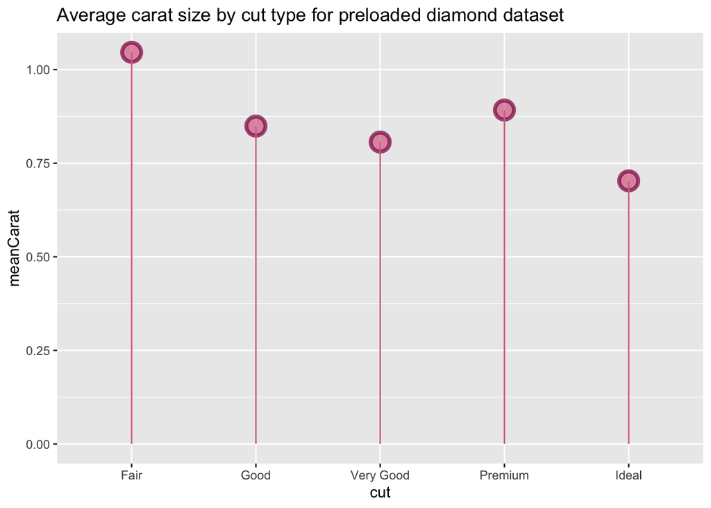

```r
DiamondMeans <- select(diamonds, carat:cut) # this makes a new df that selects only the 2 columns I care about
diamondCuts <- group_by(DiamondMeans, cut) # this groups the new df by type of cut
avgCarat <- summarize(diamondCuts, meanCarat = mean(carat))

cutVcarat <- ggplot(avgCarat, aes(x=cut, y=meanCarat)) +
  geom_point(size=5, color="deeppink4", fill=alpha("palevioletred", 0.3), alpha=0.7, shape=21, stroke=2) +
  geom_segment(aes(x=cut, xend=cut, y=0, yend=meanCarat), color="palevioletred") +
  ggtitle("Average carat size by cut type for preloaded diamond dataset")
print(cutVcarat)
```

I was surprised by this data because I was expecting the higher quality cuts to have a greater average mean carat in comparison to the “fair” and “good” diamonds!